# Scripting ImageJ using Groovy

J. R. Minter

Started: 2019-05-22, Last modified: 2019-06-03

Back to ImageJ

# 1 Introduction

## 1.1 Why Groovy?

My “*Go-To*” Fiji/ImageJ scripting language has been Jython. Jython has a problem - it **still uses** Python 2 and is not actively being updated. Fiji and ImageJ2 are rapidly developing and have a different object model and syntax than legacy ImageJ1. But I have a lot of Jython functions in a library (`jmFijGen.py`) that is maintained under version control (git) and copies “live” in `Fiji.app/jars/Lib` and so these functions can be called and reused in jython scripts that are run in the script editor.

I would like to migrate to Groovy or Python if possible.

- Note that there is fijibin on github which is supposed to be a python interface, but it has not been updated since 2015-04-22. It also runs in headless mode. It did run under Python 3.4…
- There is also [PyimageJ](https://nbviewer.jupyter.org/github/imagej/tutorials/blob/master/notebooks/1-Using-ImageJ/6-ImageJ-with-Python-Kernel.ipynb) which lets the user interact with ImageJ.
- Jan Eglinger (imagejan on the forum.image.sc) is a proponent of Groovy for understandable scripting in Fiji/ImageJ. He wrote:

  > In Groovy, you can just as well write:

  > ```
  > image = IJ.getImage()
  > ```

  > Isn’t that simple enough?

  > You can even write:

  > ```
  > image1 = IJ.openImage("/path/to/image/One.tif")
  > image2 = IJ.openImage("/path/to/image/Two.tif")
  >
  > results = []
  >
  > [image1, image2].each { image ->
  >    statistics = image.getStatistics()
  >    results << statistics.mean
  > }
  >
  > println results
  > ```

- The main site for Groovy is [groovy-lang.org](http://groovy-lang.org/).
- There is a [Groovy Scripting](https://imagej.net/Groovy_Scripting) page on ImageJ.net that refers to the Groovy [Getting Started](http://groovy-lang.org/documentation.html#gettingstarted) page.
- Source Forge example scripts **From [here](http://ij-plugins.sourceforge.net/plugins/groovy/examples.html)** listed as **retired**… These are useful template examples. There is an accompanying PDF that I archived here.
- [Groovy Syntax](http://groovy-lang.org/syntax.html)

I had a *terrible* time installing Groovy on my Win 7 system (crunch). I could not get the installer file to choose a 64 bit java and when it used my 32 bit JDK the program crashed on start up.

I ended using the brute force approach: I downloaded the [zip file](https://dl.bintray.com/groovy/maven/apache-groovy-binary-2.5.7.zip) unzipped it and installed it in `C:/Apps/groovy\groovy-2.5.7` (I 7-zipped the installation and stored it in`Dropbox/groovy/groovy-2.5.7.7z` I created a batch file `start_groovy_console.bat` that I install in `C:/Apps/local/path`. I created a Windows shortcut `start_groovy_console` that sits on my desktop. It works…

I have a simple groovy script here that uses a 32 bit image of my head shot.

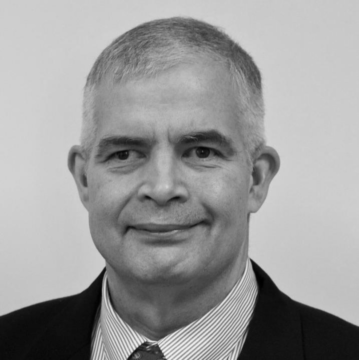

.

## 1.2 Batch Processing

This script batch processes all images with extension “.png” in the input directory. Applies a median filter to each, and saves them in the output directory.

```
import ij.*

//
// Process files with given extension.
//

// Names with extension .png
def nameFilter = ~/.*.png/

// Input directory
def inputDir = new File("my_input_dir");

// Output directory
def outputDir = new File("my_output_dir");
outputDir.mkdirs();

// List all files with extension ".png"
def inputFiles = new ArrayList<File>()
inputDir.eachFileMatch(nameFilter) {inputFiles.add(it)}

// Iterate through all input files
inputFiles.each { inputFile ->
  def src = IJ.openImage(inputFile.absolutePath)
  def dest = process(src)
  def outputFile = new File(outputDir, inputFile.name)
  IJ.saveAs(dest, "tif", outputFile.absolutePath)
}


def ImagePlus process(ImagePlus src) {
  // Do some processing
  IJ.run(src, "Median...", "radius=4")
  return src
}
```

## 1.3 Process Current ImageJ Image

This IJ1 script gets a reference to currently selected image in ImageJ then applies median filter to it. If no image is opened shows “No image” error message.

```
import ij.IJ

process()

def process() {
  // Get currently selected image
  def imp = IJ.image
  if (imp == null) {
    // Show error message
    IJ.noImage()
    return
  }

  // Do some processing
  IJ.run(imp, "Median...", "radius=4")
  // ...
}
```

## 1.4 Save Image with a Transparency

Example of using Java API to create and save an image with an alpha channel (translucent).

```
import ij.process.*
import java.awt.*
import java.awt.color.*
import java.awt.image.*
import javax.imageio.ImageIO

def ColorProcessor cp // = ...
def ByteProcessor alpha // = ...
def BufferedImage bi = createTransparent(cp, alpha)
ImageIO.write(bi, "PNG", new File("transparent-image.png"))

// Pixels with alpha equal 0 will be transparent, pixels with alpha=255 will
// be opaque, values between 0 and 255 will vary transparency.

def createTransparent(ColorProcessor src, ByteProcessor alpha) {
  def cs = ColorSpace.getInstance(ColorSpace.CS_sRGB)
  def bits = [8, 8, 8, 8] as int[]
  def cm = new ComponentColorModel(cs, bits, true, false,
                                   Transparency.BITMASK, DataBuffer.TYPE_BYTE)
  def raster = cm.createCompatibleWritableRaster(src.width, src.height)
  def dataBuffer = raster.dataBuffer as DataBufferByte

  final data = dataBuffer.data
  final n = (src.pixels as int[]).length
  final r = new byte[n]
  final g = new byte[n]
  final b = new byte[n]
  final a = (byte[]) alpha.pixels
  src.getRGB(r, g, b)
  for (int i = 0; i < n; ++i) {
    final int offset = i * 4
    data[offset] = r[i]
    data[offset + 1] = g[i]
    data[offset + 2] = b[i]
    data[offset + 3] = a[i]
  }

  return new BufferedImage(cm, raster, false, null)
}
```

Back to ImageJ